# Multi LInear Regression

### Problem Statement:-

- Build a model to predict sales of Toyota Corolla

```r
# Loading the datset.
library(readr)
ToyotaCorolla <- read_csv("/Users/thanush/Desktop/Digi 360/Module 7/Module 7_Multi Linear Regression/ToyotaCorolla.csv")
head(ToyotaCorolla)
```

```
## # A tibble: 6 x 38
##      Id Model Price Age_08_04 Mfg_Month Mfg_Year    KM Fuel_Type    HP Met_Color
##   <dbl> <chr> <dbl>     <dbl>     <dbl>    <dbl> <dbl> <chr>     <dbl>     <dbl>
## 1     1 "TOY… 13500        23        10     2002 46986 Diesel       90         1
## 2     2 "TOY… 13750        23        10     2002 72937 Diesel       90         1
## 3     3 "\xa… 13950        24         9     2002 41711 Diesel       90         1
## 4     4 "TOY… 14950        26         7     2002 48000 Diesel       90         0
## 5     5 "TOY… 13750        30         3     2002 38500 Diesel       90         0
## 6     6 "TOY… 12950        32         1     2002 61000 Diesel       90         0
## # … with 28 more variables: Color <chr>, Automatic <dbl>, cc <dbl>,
## #   Doors <dbl>, Cylinders <dbl>, Gears <dbl>, Quarterly_Tax <dbl>,
## #   Weight <dbl>, Mfr_Guarantee <dbl>, BOVAG_Guarantee <dbl>,
## #   Guarantee_Period <dbl>, ABS <dbl>, Airbag_1 <dbl>, Airbag_2 <dbl>,
## #   Airco <dbl>, Automatic_airco <dbl>, Boardcomputer <dbl>, CD_Player <dbl>,
## #   Central_Lock <dbl>, Powered_Windows <dbl>, Power_Steering <dbl>,
## #   Radio <dbl>, Mistlamps <dbl>, Sport_Model <dbl>, Backseat_Divider <dbl>,
## #   Metallic_Rim <dbl>, Radio_cassette <dbl>, Tow_Bar <dbl>
```

```r
# Extracting selected columns given in probelm statement
ToyotaCorolla <- ToyotaCorolla[,c("Price","Age_08_04","KM","HP","cc","Doors","Gears","Quarterly_Tax","Weight")]
head(ToyotaCorolla)
```

```
## # A tibble: 6 x 9
##   Price Age_08_04    KM    HP    cc Doors Gears Quarterly_Tax Weight
##   <dbl>     <dbl> <dbl> <dbl> <dbl> <dbl> <dbl>         <dbl>  <dbl>
## 1 13500        23 46986    90  2000     3     5           210   1165
## 2 13750        23 72937    90  2000     3     5           210   1165
## 3 13950        24 41711    90  2000     3     5           210   1165
## 4 14950        26 48000    90  2000     3     5           210   1165
## 5 13750        30 38500    90  2000     3     5           210   1170
## 6 12950        32 61000    90  2000     3     5           210   1170
```

```r
#Renaming the column names
colnames(ToyotaCorolla) <- c("price","age","km","hp","cc","door","gear","qrt","wgt")
head(ToyotaCorolla)
```

```
## # A tibble: 6 x 9
##   price   age    km    hp    cc  door  gear   qrt   wgt
##   <dbl> <dbl> <dbl> <dbl> <dbl> <dbl> <dbl> <dbl> <dbl>
## 1 13500    23 46986    90  2000     3     5   210  1165
## 2 13750    23 72937    90  2000     3     5   210  1165
## 3 13950    24 41711    90  2000     3     5   210  1165
## 4 14950    26 48000    90  2000     3     5   210  1165
## 5 13750    30 38500    90  2000     3     5   210  1170
## 6 12950    32 61000    90  2000     3     5   210  1170
```

```r
#Lets' see quick summary

summary(ToyotaCorolla)
```

```
##      price            age              km               hp
##  Min.   : 4350   Min.   : 1.00   Min.   :     1   Min.   : 69.0
##  1st Qu.: 8450   1st Qu.:44.00   1st Qu.: 43000   1st Qu.: 90.0
##  Median : 9900   Median :61.00   Median : 63390   Median :110.0
##  Mean   :10731   Mean   :55.95   Mean   : 68533   Mean   :101.5
##  3rd Qu.:11950   3rd Qu.:70.00   3rd Qu.: 87021   3rd Qu.:110.0
##  Max.   :32500   Max.   :80.00   Max.   :243000   Max.   :192.0
##        cc             door            gear            qrt
##  Min.   : 1300   Min.   :2.000   Min.   :3.000   Min.   : 19.00
##  1st Qu.: 1400   1st Qu.:3.000   1st Qu.:5.000   1st Qu.: 69.00
##  Median : 1600   Median :4.000   Median :5.000   Median : 85.00
##  Mean   : 1577   Mean   :4.033   Mean   :5.026   Mean   : 87.12
##  3rd Qu.: 1600   3rd Qu.:5.000   3rd Qu.:5.000   3rd Qu.: 85.00
##  Max.   :16000   Max.   :5.000   Max.   :6.000   Max.   :283.00
##       wgt
##  Min.   :1000
##  1st Qu.:1040
##  Median :1070
##  Mean   :1072
##  3rd Qu.:1085
##  Max.   :1615
```

```r
# Attching the dataframe
attach(ToyotaCorolla)
```

### Data Visualization

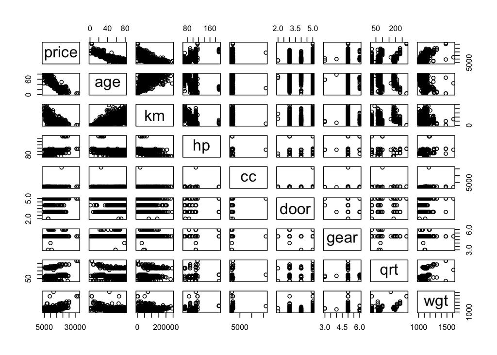

```r
plot(ToyotaCorolla)
```

```r
#Finding correlation coefficient
cor(ToyotaCorolla)
```

```
##             price          age          km          hp          cc        door
## price  1.00000000 -0.876590497 -0.56996016  0.31498983  0.12638920  0.18532555
## age   -0.87659050  1.000000000  0.50567218 -0.15662202 -0.09808374 -0.14835921
## km    -0.56996016  0.505672180  1.00000000 -0.33353795  0.10268289 -0.03619661
## hp     0.31498983 -0.156622020 -0.33353795  1.00000000  0.03585580  0.09242450
## cc     0.12638920 -0.098083739  0.10268289  0.03585580  1.00000000  0.07990330
## door   0.18532555 -0.148359215 -0.03619661  0.09242450  0.07990330  1.00000000
## gear   0.06310386 -0.005363947  0.01502333  0.20947715  0.01462935 -0.16014143
## qrt    0.21919691 -0.198430508  0.27816470 -0.29843172  0.30699580  0.10936323
## wgt    0.58119759 -0.470253184 -0.02859846  0.08961406  0.33563740  0.30261764
##               gear          qrt         wgt
## price  0.063103857  0.219196911  0.58119759
## age   -0.005363947 -0.198430508 -0.47025318
## km     0.015023328  0.278164697 -0.02859846
## hp     0.209477146 -0.298431717  0.08961406
## cc     0.014629352  0.306995798  0.33563740
## door  -0.160141430  0.109363225  0.30261764
## gear   1.000000000 -0.005451955  0.02061328
## qrt   -0.005451955  1.000000000  0.62613373
## wgt    0.020613284  0.626133733  1.00000000
```

We can see from above matrix that there are no features are closely correlated with each other.

### Model Building

```r
model1 <- lm(price~age+km+hp+cc+door+gear+qrt+wgt)
summary(model1)
```

```
##
## Call:
## lm(formula = price ~ age + km + hp + cc + door + gear + qrt +
##     wgt)
##
## Residuals:
##     Min      1Q  Median      3Q     Max
## -9366.4  -793.3   -21.3   799.7  6444.0
##
## Coefficients:
##               Estimate Std. Error t value Pr(>|t|)
## (Intercept) -5.573e+03  1.411e+03  -3.949 8.24e-05 ***
## age         -1.217e+02  2.616e+00 -46.512  < 2e-16 ***
## km          -2.082e-02  1.252e-03 -16.622  < 2e-16 ***
## hp           3.168e+01  2.818e+00  11.241  < 2e-16 ***
## cc          -1.211e-01  9.009e-02  -1.344  0.17909
## door        -1.617e+00  4.001e+01  -0.040  0.96777
## gear         5.943e+02  1.971e+02   3.016  0.00261 **
## qrt          3.949e+00  1.310e+00   3.015  0.00262 **
## wgt          1.696e+01  1.068e+00  15.880  < 2e-16 ***
## ---
## Signif. codes:  0 '***' 0.001 '**' 0.01 '*' 0.05 '.' 0.1 ' ' 1
##
## Residual standard error: 1342 on 1427 degrees of freedom
## Multiple R-squared:  0.8638, Adjusted R-squared:  0.863
## F-statistic:  1131 on 8 and 1427 DF,  p-value: < 2.2e-16
```

### Checking VIF

```r
library(car)
vif(model1)
```

```
##      age       km       hp       cc     door     gear      qrt      wgt
## 1.884620 1.756905 1.419422 1.163894 1.156575 1.098723 2.311431 2.516420
```

Here the VIF is less than 5. So, no variable is collinear with others. So, let’s remove the features which are having insignificant p values

Let’s remove `cc` and `doors` since they have p value greater than 0.05.

```r
#Building the model after dropping the cc and doors variable

model2 <- lm(price~age+km+hp+gear+qrt+wgt)
summary(model2)
```

```
##
## Call:
## lm(formula = price ~ age + km + hp + gear + qrt + wgt)
##
## Residuals:
##     Min      1Q  Median      3Q     Max
## -9224.7  -792.3   -25.5   801.9  6436.6
##
## Coefficients:
##               Estimate Std. Error t value Pr(>|t|)
## (Intercept) -5.478e+03  1.409e+03  -3.889 0.000105 ***
## age         -1.217e+02  2.615e+00 -46.534  < 2e-16 ***
## km          -2.094e-02  1.249e-03 -16.769  < 2e-16 ***
## hp           3.133e+01  2.799e+00  11.191  < 2e-16 ***
## gear         5.990e+02  1.934e+02   3.096 0.001997 **
## qrt          3.737e+00  1.296e+00   2.883 0.003999 **
## wgt          1.673e+01  1.020e+00  16.393  < 2e-16 ***
## ---
## Signif. codes:  0 '***' 0.001 '**' 0.01 '*' 0.05 '.' 0.1 ' ' 1
##
## Residual standard error: 1342 on 1429 degrees of freedom
## Multiple R-squared:  0.8636, Adjusted R-squared:  0.863
## F-statistic:  1508 on 6 and 1429 DF,  p-value: < 2.2e-16
```

Here p value is significant so we reject the null hypothesis. That means there is significant correlation between price vs other input variables.

Here we also can see R-squared value is 0.8636 which is greater than 0.85. Hence our model is good and we don’t need further transformations.

### Splitting the dataset into Train and Test

```r
n=nrow(ToyotaCorolla)
n1=n*0.7
n2=n-n1
train=sample(1:n,n1)
test=ToyotaCorolla[-train,]
```

### Predicting the values with model 2

```r
pred=predict(model2,newdata = test)
actual=test$price
```

```r
#Finding the errors
error=actual-pred
```

### Fnding the Accuracy

```r
test.rmse=sqrt(mean(error**2))
test.rmse
```

```
## [1] 1240.221
```

```r
train.rmse=sqrt(mean(model2$residuals**2))
train.rmse
```

```
## [1] 1339.106
```

Here we can see test rmse value is very close to train rmse value. So, our model is significantly fit.

### R^2 value for two models: -

Model 1 0.8638 Model 2 0.8636

### Conclusion

- R^2 of the model is 0.86 which is good
- RMSE is very close for both train and test sets

We can conclude that the sales of the Corolla depends on the features `age`, `km`, `hp`, `gear`, `quarterly tax` and `weight`.